# Your Digest for Monday, Feb 12, 2024 11:59 PM

# Optic neuritis

*Impairment of visual **acuity*** over *hours to days* *with occular pain (worsening with eye movement) and loss of **colour** vision* out of proportion to loss of acuity.

> Loss of *colour vision* > loss of acuity = specific to optic nerve pathology

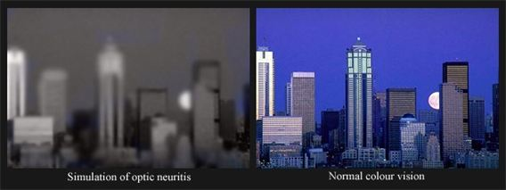

# Transverse myelitis

> Transverse myelitis (TM) is a rare, **acquired focal inflammatory disorder** of the spinal cord often presenting with *rapid onset weakness, sensory deficits, and bowel/bladder dysfunction*.

> *perivascular infiltration*, *demyelination*, and *axonal injury* by monocytes and lymphocytes at the lesion site. (Gray and white matter is involved so it's not purely demyelinating).
- Most common cause is **idiopathic**
- Infections leading to TM include, but are not limited to, enteroviruses, West Nile virus, **herpes viruses**, **HIV**, human T-cell leukemia virus type 1 (HTLV-1), Zika virus, neuroborreliosis (**Lyme**), *Mycoplasma*, and *Treponema pallidum*

[figure not shown]